# R Notebook

**import library**

```r
library(tidyverse)
library(ggplot2)
library(markovchain)
library(dplyr)
library(patchwork)
library(hrbrthemes)
```

**loading of data.**

```r
data_text <- readxl::read_xlsx(path = "WholeData_cardano_adaCoin.xlsx")
data_score <- readxl::read_xlsx(path = "Cardano_ada_data (2).xlsx")
```

```r
glimpse(x = data_text)
```

```
Rows: 5,188
Columns: 18
$ id               <dbl> 1, 1, 2, 3, 1, 2, 3, 4, 5, 1, 2, 3, 4, 5, 6, 7, 8, 9, 10, 11, 12, 13, 14, 15, 16, 17, 18, 1…
$ structure        <chr> "1", "1", "2", "3", "1", "2", "2_1", "3", "3_1", "1", "2", "2_1", "2_1_1", "2_1_1_1", "2_1_…
$ post_date        <dttm> 2021-06-20 06:00:32, 2021-06-19 06:04:09, 2021-06-19 06:04:09, 2021-06-19 06:04:09, 2021-0…
$ comm_date        <dttm> 2021-06-20 06:00:33, 2021-06-19 06:04:10, 2021-06-19 07:04:48, 2021-06-19 10:59:02, 2021-0…
$ num_comments     <dbl> 1, 3, 3, 3, 6, 6, 6, 6, 6, 38, 38, 38, 38, 38, 38, 38, 38, 38, 38, 38, 38, 38, 38, 38, 38, …
$ subreddit        <chr> "cardano", "cardano", "cardano", "cardano", "cardano", "cardano", "cardano", "cardano", "ca…
$ upvote_prop      <dbl> 0.82, 0.94, 0.94, 0.94, 0.90, 0.90, 0.90, 0.90, 0.90, 0.32, 0.32, 0.32, 0.32, 0.32, 0.32, 0…
$ post_score       <dbl> 10, 59, 59, 59, 27, 27, 27, 27, 27, 0, 0, 0, 0, 0, 0, 0, 0, 0, 0, 0, 0, 0, 0, 0, 0, 0, 0, 0…
$ author           <chr> "ArmyofSpies", "ArmyofSpies", "ArmyofSpies", "ArmyofSpies", "ArmyofSpies", "ArmyofSpies", "…
$ user             <chr> "AutoModerator", "AutoModerator", "Nitroe01", "Maleficiente", "AutoModerator", "Nitroe01", …
$ comment_score    <dbl> 1, 1, 6, 2, 1, 2, 2, 1, 2, 1, 25, 1, 5, -1, 3, 3, 1, 8, -2, 2, 1, 1, 7, 7, 8, 3, 7, 1, 2, 2…
$ controversiality <dbl> 0, 0, 0, 0, 0, 0, 0, 0, 0, 0, 0, 1, 0, 0, 0, 0, 0, 0, 0, 0, 0, 0, 0, 0, 0, 0, 0, 0, 0, 0, 0…
$ comment          <chr> "\r\n* [**NEWBIES GUIDE**](https://www.reddit.com/r/cardano/comments/lnj5ne/getting_started…
$ title            <chr> "Cardano Rumor Rundown June 20, 2021", "Cardano Rumor Rundown June 19, 2021", "Cardano Rumo…
$ post_text        <chr> "Hey Everyone!\r\n\r\nLet's go...\r\n\r\nNewly covered today: \r\n\r\n1. Cardano 360 is thi…
$ link             <chr> "https://www.reddit.com/r/cardano/comments/o3yvjk/cardano_rumor_rundown_june_20_2021/", "ht…
$ domain           <chr> "self.cardano", "self.cardano", "self.cardano", "self.cardano", "self.cardano", "self.carda…
$ URL              <chr> "http://www.reddit.com/r/cardano/comments/o3yvjk/cardano_rumor_rundown_june_20_2021/?ref=se…
```

```r
# data_text$comment[1]
glimpse(data_score)
```

```
Rows: 65
Columns: 7
$ Date       <chr> "Jun 20, 2021", "Jun 19, 2021", "Jun 18, 2021", "Jun 17, 2021", "Jun 16, 2021", "Jun 15, 2021", "…
$ Price      <dbl> 1.393800, 1.385523, 1.412945, 1.481025, 1.483329, 1.556513, 1.575848, 1.558645, 1.477178, 1.43600…
$ Open       <dbl> 1.385596, 1.412691, 1.480926, 1.484275, 1.556441, 1.575679, 1.558489, 1.477265, 1.436233, 1.53153…
$ High       <dbl> 1.413965, 1.440531, 1.492570, 1.538041, 1.574656, 1.610409, 1.593421, 1.579148, 1.492281, 1.54505…
$ Low        <dbl> 1.306566, 1.383759, 1.375567, 1.457983, 1.474576, 1.544820, 1.508744, 1.400833, 1.357757, 1.41933…
$ Vol.       <chr> "390.44M", "323.50M", "386.36M", "311.28M", "385.43M", "382.73M", "495.19M", "594.54M", "566.56M"…
$ `Change %` <dbl> 0.0060, -0.0194, -0.0460, -0.0016, -0.0470, -0.0123, 0.0110, 0.0552, 0.0287, -0.0624, -0.0574, 0.…
```

*Transformacion de variables de fecha*

```r
# removemos la coma de las fecha para el inner join.
data_score <- data_score %>%
  mutate(Date = str_replace_all(Date, ",", ""))
```

```r
# manejando expresiones regulares
data_score <- data_score %>%
  mutate(Date = sub(pattern="?Jun", c("June"), Date)) %>%
  mutate(Date = sub(pattern="?Apr", c("April"), Date))

data_text <- data_text %>%
  mutate(comm_date = format(comm_date, format = "%B %d %Y")) %>%
  mutate(post_date = format(post_date, format = "%B %d %Y"))

# cambiamos el nombre de la variables comm_date a Date para el inner join
data_text <- reshape::rename(data_text, c(comm_date = "Date"))
names(data_text)
```

```
 [1] "id"               "structure"        "post_date"        "Date"             "num_comments"
 [6] "subreddit"        "upvote_prop"      "post_score"       "author"           "user"
[11] "comment_score"    "controversiality" "comment"          "title"            "post_text"
[16] "link"             "domain"           "URL"
```

| Date | Price | Open | High | Low | Vol. | Change % |
| --- | --- | --- | --- | --- | --- | --- |
| 2021-06-20 | 1.393800 | 1.385596 | 1.413965 | 1.306566 | 390.44M | 0.0060 |
| 2021-06-19 | 1.385523 | 1.412691 | 1.440531 | 1.383759 | 323.50M | -0.0194 |
| 2021-06-18 | 1.412945 | 1.480926 | 1.492570 | 1.375567 | 386.36M | -0.0460 |
| 2021-06-17 | 1.481025 | 1.484275 | 1.538041 | 1.457983 | 311.28M | -0.0016 |
| 2021-06-16 | 1.483329 | 1.556441 | 1.574656 | 1.474576 | 385.43M | -0.0470 |
| 2021-06-15 | 1.556513 | 1.575679 | 1.610409 | 1.544820 | 382.73M | -0.0123 |
| 2021-06-14 | 1.575848 | 1.558489 | 1.593421 | 1.508744 | 495.19M | 0.0110 |
| 2021-06-13 | 1.558645 | 1.477265 | 1.579148 | 1.400833 | 594.54M | 0.0552 |
| 2021-06-12 | 1.477178 | 1.436233 | 1.492281 | 1.357757 | 566.56M | 0.0287 |
| 2021-06-11 | 1.436004 | 1.531531 | 1.545059 | 1.419333 | 442.16M | -0.0624 |

[output cut: 55 more lines]

**Creacion del dataframe sobre correlacion**

| Date | id | comment_score | Price |
| --- | --- | --- | --- |
| 2021-06-20 | 1 | 1 | 1.393800 |
| 2021-06-19 | 1 | 1 | 1.385523 |
| 2021-06-19 | 2 | 6 | 1.385523 |
| 2021-06-19 | 3 | 2 | 1.385523 |
| 2021-06-18 | 1 | 1 | 1.412945 |
| 2021-06-18 | 2 | 2 | 1.412945 |
| 2021-06-18 | 3 | 2 | 1.412945 |
| 2021-06-18 | 4 | 1 | 1.412945 |
| 2021-06-18 | 5 | 2 | 1.412945 |
| 2021-06-18 | 8 | 1 | 1.412945 |

[output cut: 990 more lines]

**prueba de normalidad de los datos**

```r
shapiro.test(df_cor$comment_score)
```

```
    Shapiro-Wilk normality test

data:  df_cor$comment_score
W = 0.26052, p-value < 2.2e-16
```

observacion: dado que el valor de p-value es menor que 0.05 (alfa) entonces diremos que no existe evidencia suficiente para no rechazar la hipotesis nula de que los datos de la muestra provienen de una poblacion con distribucion normal. por lo tanto, los datos del puntaje de los comentarios no provienen de una distribucion normal.

```r
shapiro.test(df_cor$Price)
```

```
    Shapiro-Wilk normality test

data:  df_cor$Price
W = 0.96705, p-value < 2.2e-16
```

observacion: dado que el valor de p-value es menor que 0.05 (alfa) entonces diremos que no existe evidencia suficiente para no rechazar la hipotesis nula de que los datos de la muestra provienen de una poblacion con distribucion normal. por lo tanto, los datos del precio de la criptomoneda no provienen de una distribucion normal.

**graficos**

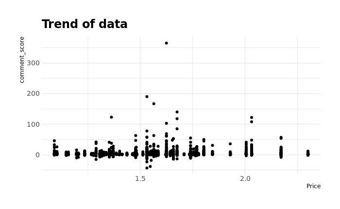

Observacion: Como podemos ver, tenemos una tendencia nula, con una fuerza de correlacion debil.

```r
# coeficiente de correlacion de Spearman
cor(x=df_cor$comment_score, y=df_cor$Price, method="spearman")
```

```
[1] 0.02909834
```

observacion: cuantitativamente podemos oberservar que la correlacion de los datos es casi nula

*Grafico de series temporales*

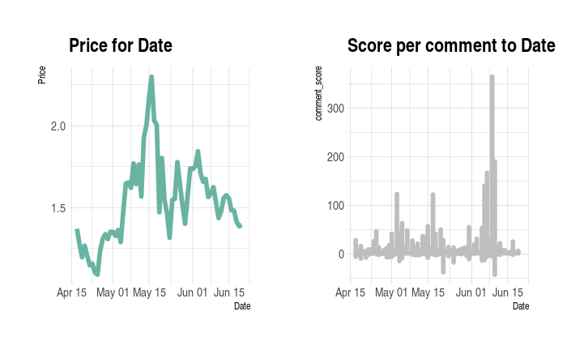

Observaciones: los grafics de series temporales nos muestra un aumento en el precio de la criptomoneda durante el mes de mayo. asi mismo durante este periodo, es posible observar que los puntos de los comentarios han aumentado. por el contrario durante el mes de junio podemos ver una caida del precio que no corresponderia al puntaje de los comentarios de los usuarios de reddit para compras de criptomonedas.

**Modelo HMM**

| Date | Price | comment |
| --- | --- | --- |
| 2021-06-20 | 1.393800 | \r\n* [**NEWBIES GUIDE**](https://www.reddit.com/r/cardano/comments/lnj5ne/getting_started_guide_a_newbies_guide_to_cardano/) *Ensure you've read this guide or your post may be removed.*\r\n* [**PROJE… |
| 2021-06-20 | 1.393800 | \r\n* [**NEWBIES GUIDE**](https://www.reddit.com/r/cardano/comments/lnj5ne/getting_started_guide_a_newbies_guide_to_cardano/) *Ensure you've read this guide or your post may be removed.*\r\n* [**PROJE… |
| 2021-06-19 | 1.385523 | \r\n* [**NEWBIES GUIDE**](https://www.reddit.com/r/cardano/comments/lnj5ne/getting_started_guide_a_newbies_guide_to_cardano/) *Ensure you've read this guide or your post may be removed.*\r\n* [**PROJE… |
| 2021-06-19 | 1.385523 | Thanks for your research!\r\nLets hope crypto will be an attractive investment for people who buy empty houses for their portfolio..\r\nSell the house, buy ADA =? |
| 2021-06-19 | 1.385523 | Thanks for the excellent summary! Much appreciate all your work compiling this |
| 2021-06-18 | 1.412945 | \r\n* [**NEWBIES GUIDE**](https://www.reddit.com/r/cardano/comments/lnj5ne/getting_started_guide_a_newbies_guide_to_cardano/) *Ensure you've read this guide or your post may be removed.*\r\n* [**PROJE… |
| 2021-06-18 | 1.412945 | Thanks for the update! :) |
| 2021-06-18 | 1.412945 | Thanks for reading, Nitroe01! |
| 2021-06-18 | 1.412945 | Thanks! |
| 2021-06-18 | 1.412945 | Thanks for reading, Jerjon89. |

[output cut: 990 more lines]

```r
mc <- new("markovchain", transitionMatrix=m_price, states = df_hmm$comment, name = "comments")
```

```
Error in dimnames(x) <- dn :
  length of 'dimnames' [2] not equal to array extent
```